# machine learning

Santhosh reddy Mallikireddy

12/11/2019

```r
library(ISLR)
library(readr)
library(tidyverse)  # data manipulation
library(cluster)    # clustering algorithms
library(factoextra) # clustering visualization
```

```r
library(dendextend) # for comparing two dendrograms
cereals <- read_csv("Cereals (1).csv")
#View(cereals)
set.seed(123)
summary(cereals)
```

```
##      name               mfr                type              calories
##  Length:77          Length:77          Length:77          Min.   : 50.0
##  Class :character   Class :character   Class :character   1st Qu.:100.0
##  Mode  :character   Mode  :character   Mode  :character   Median :110.0
##                                                           Mean   :106.9
##                                                           3rd Qu.:110.0
##                                                           Max.   :160.0
##
##     protein           fat            sodium          fiber
##  Min.   :1.000   Min.   :0.000   Min.   :  0.0   Min.   : 0.000
##  1st Qu.:2.000   1st Qu.:0.000   1st Qu.:130.0   1st Qu.: 1.000
##  Median :3.000   Median :1.000   Median :180.0   Median : 2.000
##  Mean   :2.545   Mean   :1.013   Mean   :159.7   Mean   : 2.152
##  3rd Qu.:3.000   3rd Qu.:2.000   3rd Qu.:210.0   3rd Qu.: 3.000
##  Max.   :6.000   Max.   :5.000   Max.   :320.0   Max.   :14.000
##
##      carbo          sugars           potass          vitamins
##  Min.   : 5.0   Min.   : 0.000   Min.   : 15.00   Min.   :  0.00
##  1st Qu.:12.0   1st Qu.: 3.000   1st Qu.: 42.50   1st Qu.: 25.00
##  Median :14.5   Median : 7.000   Median : 90.00   Median : 25.00
##  Mean   :14.8   Mean   : 7.026   Mean   : 98.67   Mean   : 28.25
##  3rd Qu.:17.0   3rd Qu.:11.000   3rd Qu.:120.00   3rd Qu.: 25.00
##  Max.   :23.0   Max.   :15.000   Max.   :330.00   Max.   :100.00
##  NA's   :1      NA's   :1        NA's   :2
##      shelf           weight          cups           rating
##  Min.   :1.000   Min.   :0.50   Min.   :0.250   Min.   :18.04
##  1st Qu.:1.000   1st Qu.:1.00   1st Qu.:0.670   1st Qu.:33.17
##  Median :2.000   Median :1.00   Median :0.750   Median :40.40
##  Mean   :2.208   Mean   :1.03   Mean   :0.821   Mean   :42.67
##  3rd Qu.:3.000   3rd Qu.:1.00   3rd Qu.:1.000   3rd Qu.:50.83
##  Max.   :3.000   Max.   :1.50   Max.   :1.500   Max.   :93.70
##
```

```r
cereals.norm <- cereals[,-c(1:3)]
#cereals.norm <- cbind(cereals[,1:3],cereals.norm)
cereals.norm <- na.omit(cereals.norm)
cereals.norm <- scale(cereals.norm)
C_main <- as.data.frame(cereals.norm)
View(cereals.norm)
summary(cereals.norm)
```

```
##     calories          protein              fat              sodium
##  Min.   :-2.8738   Min.   :-1.40687   Min.   :-0.9932   Min.   :-1.9616
##  1st Qu.:-0.3541   1st Qu.:-0.47733   1st Qu.:-0.9932   1st Qu.:-0.3306
##  Median : 0.1498   Median :-0.01256   Median : 0.0000   Median : 0.2131
##  Mean   : 0.0000   Mean   : 0.00000   Mean   : 0.0000   Mean   : 0.0000
##  3rd Qu.: 0.1498   3rd Qu.: 0.45221   3rd Qu.: 0.0000   3rd Qu.: 0.6661
##  Max.   : 2.6695   Max.   : 3.24083   Max.   : 3.9729   Max.   : 1.9045
##      fiber              carbo              sugars            potass
##  Min.   :-0.89778   Min.   :-2.50014   Min.   :-1.6306   Min.   :-1.1783
##  1st Qu.:-0.79462   1st Qu.:-0.70143   1st Qu.:-0.9424   1st Qu.:-0.8079
##  Median :-0.07249   Median :-0.05903   Median :-0.0248   Median :-0.1201
##  Mean   : 0.00000   Mean   : 0.00000   Mean   : 0.0000   Mean   : 0.0000
##  3rd Qu.: 0.34015   3rd Qu.: 0.58337   3rd Qu.: 0.8928   3rd Qu.: 0.3031
##  Max.   : 4.87925   Max.   : 2.12512   Max.   : 1.8104   Max.   : 3.2660
##     vitamins           shelf             weight             cups
##  Min.   :-1.3032   Min.   :-1.4617   Min.   :-3.4600   Min.   :-2.4251
##  1st Qu.:-0.1818   1st Qu.:-1.1612   1st Qu.:-0.2008   1st Qu.:-0.6432
##  Median :-0.1818   Median :-0.2599   Median :-0.2008   Median :-0.3038
##  Mean   : 0.0000   Mean   : 0.0000   Mean   : 0.0000   Mean   : 0.0000
##  3rd Qu.:-0.1818   3rd Qu.: 0.9420   3rd Qu.:-0.2008   3rd Qu.: 0.7568
##  Max.   : 3.1822   Max.   : 0.9420   Max.   : 3.0583   Max.   : 2.8780
##      rating
##  Min.   :-1.7336
##  1st Qu.:-0.7071
##  Median :-0.1510
##  Mean   : 0.0000
##  3rd Qu.: 0.5807
##  Max.   : 3.6578
```

Q1:Apply hierarchical clustering to the data using Euclidean distance to the normalized measurements. Use Agnes to compare the clustering from single linkage, complete linkage, average linkage, and Ward. Choose the best method.

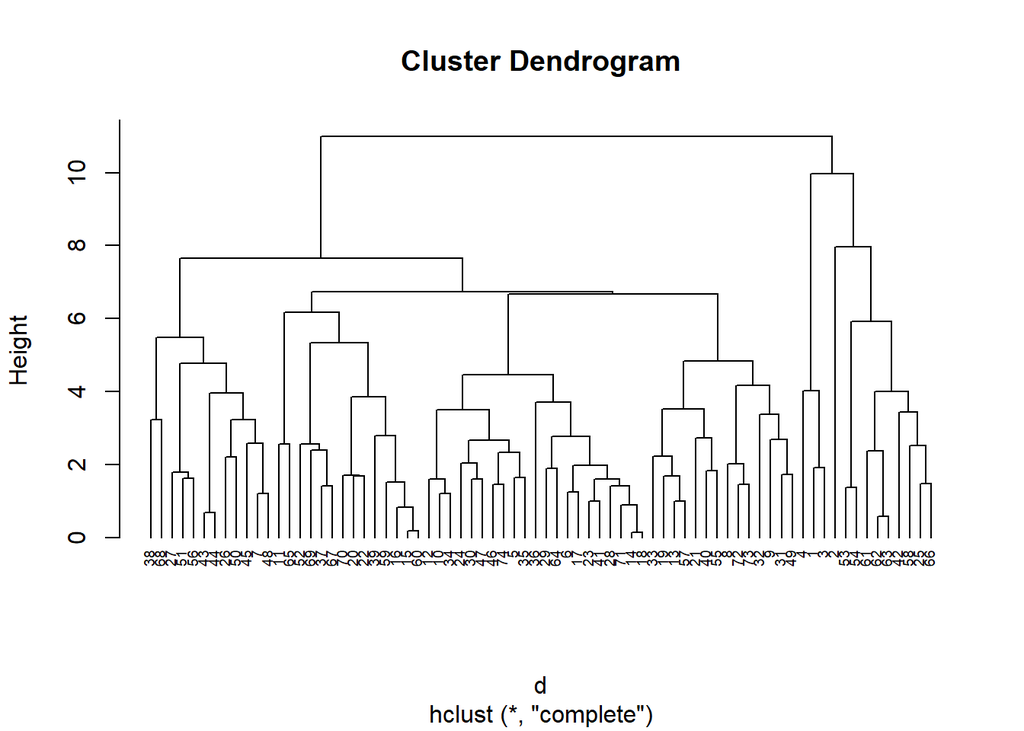

```r
# Dissimilarity matrix
d <- dist(cereals.norm, method = "euclidean")

# Hierarchical clustering using Complete Linkage
hc1 <- hclust(d, method = "complete" )

# Plot the obtained dendrogram
plot(hc1, cex = 0.6, hang = -1)
```

```r
# methods to assess
m <- c( "average", "single", "complete", "ward")
names(m) <- c( "average", "single", "complete", "ward")

# function to compute coefficient
ac <- function(x) {
  agnes(cereals.norm, method = x)$ac
}

map_dbl(m, ac)
```

```
##   average    single  complete      ward
## 0.7766075 0.6067859 0.8353712 0.9046042
```

From the above result “ward” is the best method.

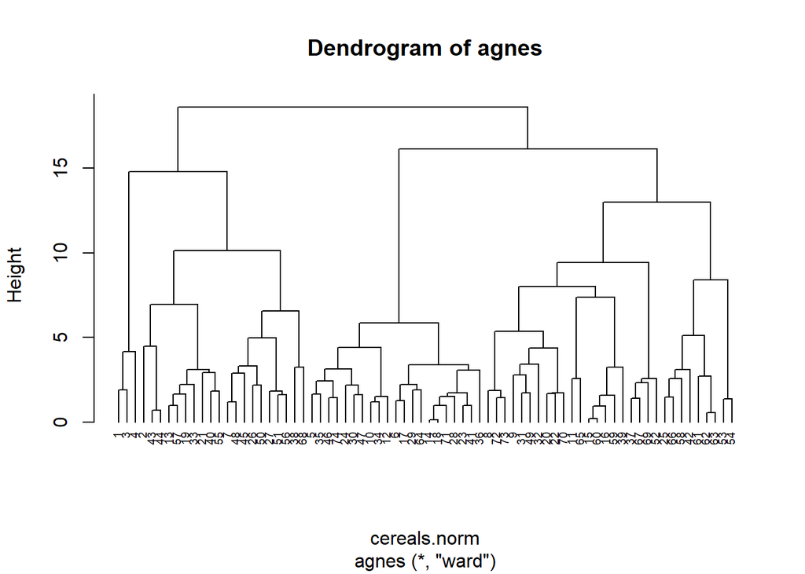

```r
hc2 <- agnes(cereals.norm, method = "ward")
pltree(hc2, cex = 0.6, hang = -1, main = "Dendrogram of agnes")
```

Q2:How many clusters would you choose?

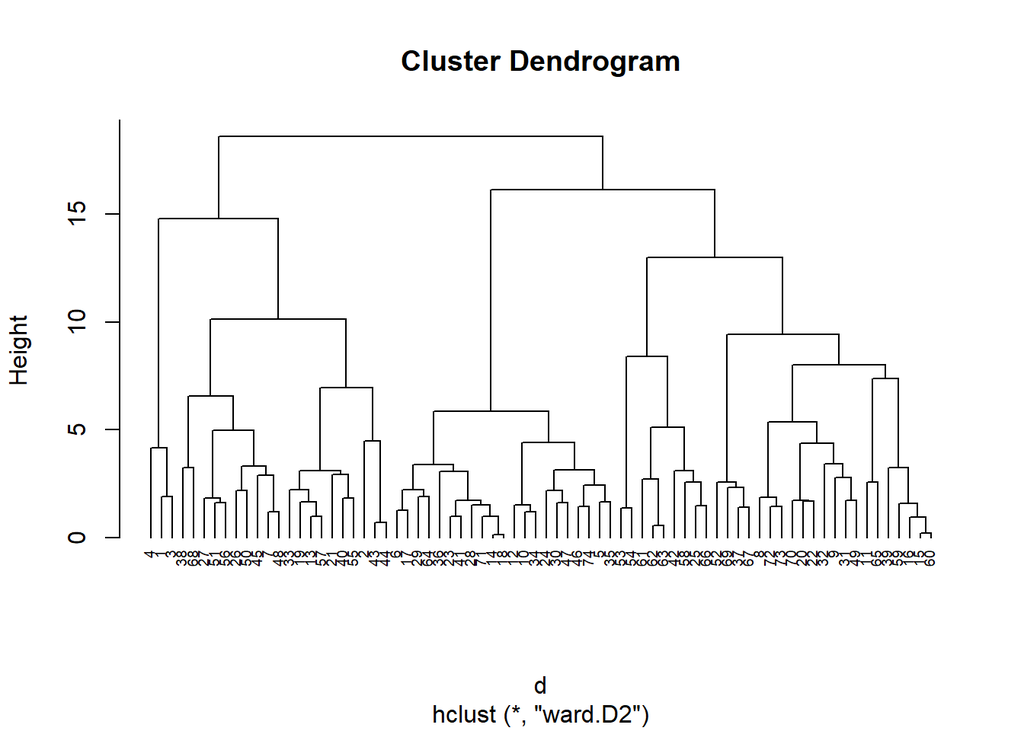

```r
d <- dist(cereals.norm, method = "euclidean")

# Hierarchical clustering using Ward Linkage
hc3 <- hclust(d, method = "ward.D2" )

# Plot the obtained dendrogram
plot(hc3, cex = 0.6, hang = -1)
```

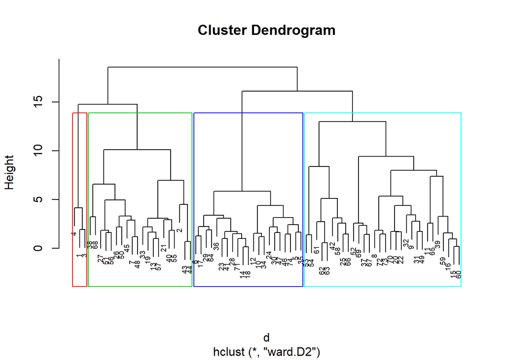

```r
sub_grp <- cutree(hc3, k = 4)
C2 <- as.data.frame(cbind(C_main,sub_grp))
plot(hc3, cex = 0.6)
rect.hclust(hc3, k = 4, border = 2:5)
```

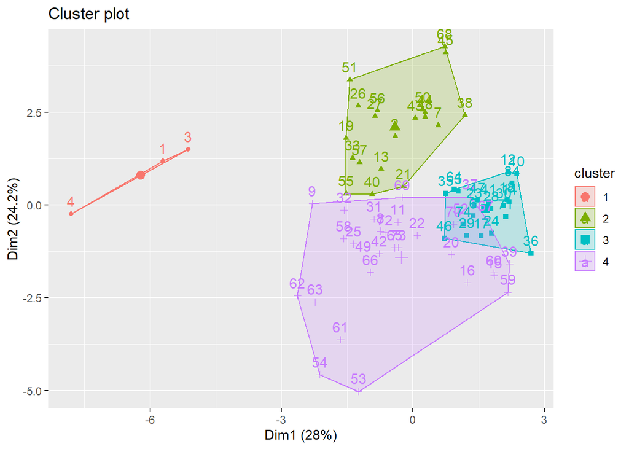

```r
fviz_cluster(list(data = cereals.norm, cluster = sub_grp))
```

k=4 is cutting the longest path, so I choose k=4.

Q3: Comment on the structure of the clusters and on their stability. Hint: To check stability, partition the data and see how well clusters formed based on one part apply to the other part. To do this: -> Cluster partition A

-> Use the cluster centroids from A to assign each record in partition B (each record is assigned to the cluster with the closest centroid).

->Assess how consistent the cluster assignments are compared to the assignments based on all the data.

```r
library(caret)
```

```r
set.seed(123)
C<-cereals
C1<-na.omit(C)


#C_index<-createDataPartition(C1$calories,p=0.5,list=FALSE)
train_data<-C1[1:50,]
test_data<-C1[51:74,]
train_data<-as.data.frame(scale(train_data[,-c(1:3)]))
test_data<-as.data.frame(scale(test_data[,-c(1:3)]))

tr <- c( "average", "single", "complete", "ward")
names(tr) <- c( "average", "single", "complete", "ward")

# function to compute coefficient
ac <- function(x) {
  agnes(train_data, method = x)$ac
}

map_dbl(tr, ac)
```

```
##   average    single  complete      ward
## 0.7408904 0.6393338 0.8138238 0.8764323
```

```r
tt <- c( "average", "single", "complete", "ward")
names(tt) <- c( "average", "single", "complete", "ward")

# function to compute coefficient
ac <- function(x) {
  agnes(test_data, method = x)$ac
}

map_dbl(tt, ac)
```

```
##   average    single  complete      ward
## 0.6407892 0.4564398 0.7675708 0.8155379
```

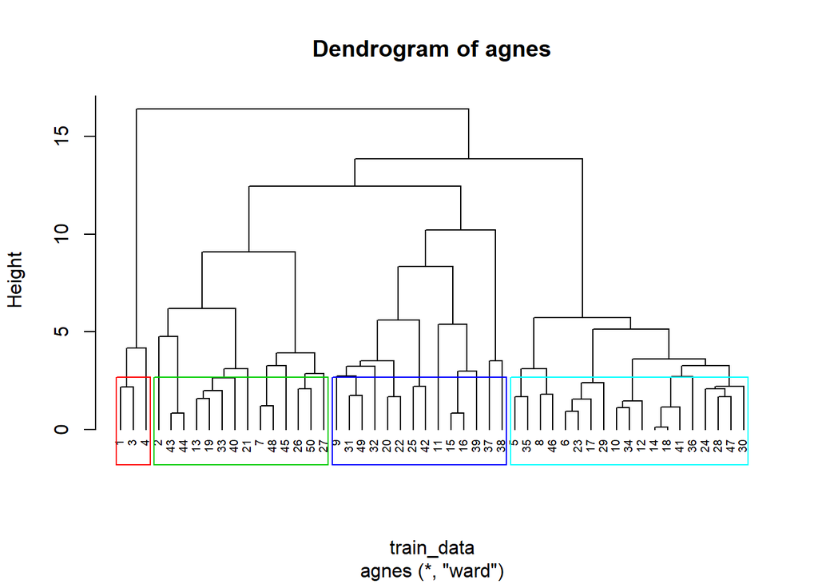

```r
hc_tr<- agnes(train_data,method = "ward")
hc_tt<- agnes(test_data,method = "ward")


pltree(hc_tr,cex=0.6,hang=-1,main="Dendrogram of agnes")
rect.hclust(hc_tr, k = 4, border = 2:5)
```

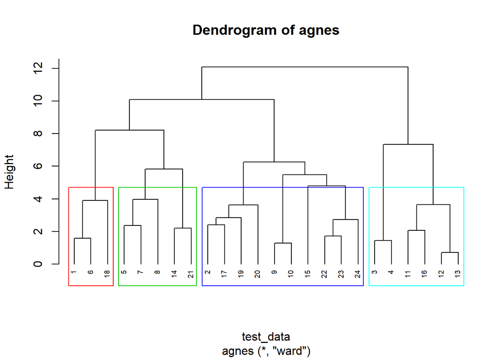

```r
pltree(hc_tt,cex=0.6,hang=-1,main="Dendrogram of agnes")
rect.hclust(hc_tt, k = 4, border = 2:5)
```

```r
hc_tr_cut <- cutree(hc_tr,k=4)
hc_tt_cut <- cutree(hc_tt,k=4)

hc_total <- as.data.frame(cbind(train_data,hc_tr_cut))
hc_total
```

```
##       calories    protein        fat      sodium       fiber       carbo
## 1  -2.10833532  1.3728129 -0.1807392 -0.59728595  2.86071640 -2.41057418
## 2   0.50099057  0.4576043  3.4340452 -2.26852401 -0.09228117 -1.61849066
## 3  -2.10833532  1.3728129 -0.1807392  1.29193968  2.49159170 -1.88251850
## 4  -3.15206567  1.3728129 -1.0844353 -0.45196090  4.33721518 -1.61849066
## 5  -0.02087461 -0.4576043  0.7229569  0.12933929 -0.27684352 -0.95842106
## 6  -0.02087461 -0.4576043 -1.0844353 -0.66994847 -0.46140587 -0.82640714
## 7   1.02285575  0.4576043  0.7229569  0.56531444 -0.09228117  1.02178774
## 8  -1.06460496 -0.4576043 -0.1807392  0.41998939  0.64596822  0.22970422
## 9  -1.06460496  0.4576043 -1.0844353  0.56531444  1.01509291 -0.29835146
## 10  0.50099057 -1.3728129  0.7229569  0.71063949 -0.83053057 -0.56237930
## 11 -0.02087461  3.2032302  0.7229569  1.72791483 -0.09228117  0.75775990
## 12  0.50099057 -1.3728129  1.6266530  0.56531444 -0.83053057 -0.29835146
## 13 -0.02087461  0.4576043  0.7229569 -0.45196090 -0.09228117 -0.29835146
## 14 -0.02087461 -1.3728129 -0.1807392  0.12933929 -0.83053057 -0.56237930
```

[output cut: 138 more lines]

```r
tr_clust1 <- hc_total[hc_total$hc_tr_cut==1,]
colMeans(tr_clust1)
```

```
##    calories     protein         fat      sodium       fiber       carbo
## -2.45624544  1.37281295 -0.48197126  0.08089761  3.22984109 -1.97052778
##      sugars      potass    vitamins       shelf      weight        cups
## -1.13045659  2.89180035 -0.16274669  0.91894945 -0.38685007 -1.66904636
##      rating   hc_tr_cut
##  2.48224609  1.00000000
```

```r
tr_clust2 <- hc_total[hc_total$hc_tr_cut==2,]
colMeans(tr_clust2)
```

```
##    calories     protein         fat      sodium       fiber       carbo
##  0.79919924  0.58834841  0.98115578 -0.35334747  0.23729445 -0.06261232
##      sugars      potass    vitamins       shelf      weight        cups
##  0.22360680  0.55258456 -0.27899433  0.82778383  0.81376073 -0.46691524
##      rating   hc_tr_cut
## -0.11897174  2.00000000
```

```r
tr_clust3 <- hc_total[hc_total$hc_tr_cut==3,]
colMeans(tr_clust3)
```

```
##    calories     protein         fat      sodium       fiber       carbo
## -0.02087461 -0.89112419 -0.18073922  0.12169061 -0.55854395 -0.36783247
##      sugars      potass    vitamins       shelf      weight        cups
##  0.76889355 -0.66748308 -0.16274669 -0.82759190 -0.38685007  0.29351178
##      rating   hc_tr_cut
## -0.75056641  3.00000000
```

```r
tr_clust4 <- hc_total[hc_total$hc_tr_cut==4,]
colMeans(tr_clust4)
```

```
##    calories     protein         fat      sodium       fiber       carbo
## -0.24453111  0.32686023 -0.63258728  0.17086074 -0.17137932  0.98406948
##      sugars      potass    vitamins       shelf      weight        cups
## -1.02486449 -0.26638617  0.53473914  0.09845887 -0.20585347  0.42623062
##      rating   hc_tr_cut
##  0.60568772  4.00000000
```

```r
hc_means1 <- rbind(colMeans(tr_clust1),colMeans(tr_clust2),colMeans(tr_clust3),colMeans(tr_clust4))
hc_means1
```

```
##         calories    protein        fat      sodium      fiber       carbo
## [1,] -2.45624544  1.3728129 -0.4819713  0.08089761  3.2298411 -1.97052778
## [2,]  0.79919924  0.5883484  0.9811558 -0.35334747  0.2372944 -0.06261232
## [3,] -0.02087461 -0.8911242 -0.1807392  0.12169061 -0.5585439 -0.36783247
## [4,] -0.24453111  0.3268602 -0.6325873  0.17086074 -0.1713793  0.98406948
##          sugars     potass   vitamins       shelf     weight       cups
## [1,] -1.1304566  2.8918004 -0.1627467  0.91894945 -0.3868501 -1.6690464
## [2,]  0.2236068  0.5525846 -0.2789943  0.82778383  0.8137607 -0.4669152
## [3,]  0.7688936 -0.6674831 -0.1627467 -0.82759190 -0.3868501  0.2935118
## [4,] -1.0248645 -0.2663862  0.5347391  0.09845887 -0.2058535  0.4262306
##          rating hc_tr_cut
## [1,]  2.4822461         1
## [2,] -0.1189717         2
## [3,] -0.7505664         3
## [4,]  0.6056877         4
```

```r
hc_means <- subset(hc_means1,select = -c(hc_tr_cut))
hc_means
```

```
##         calories    protein        fat      sodium      fiber       carbo
## [1,] -2.45624544  1.3728129 -0.4819713  0.08089761  3.2298411 -1.97052778
## [2,]  0.79919924  0.5883484  0.9811558 -0.35334747  0.2372944 -0.06261232
## [3,] -0.02087461 -0.8911242 -0.1807392  0.12169061 -0.5585439 -0.36783247
## [4,] -0.24453111  0.3268602 -0.6325873  0.17086074 -0.1713793  0.98406948
##          sugars     potass   vitamins       shelf     weight       cups
## [1,] -1.1304566  2.8918004 -0.1627467  0.91894945 -0.3868501 -1.6690464
## [2,]  0.2236068  0.5525846 -0.2789943  0.82778383  0.8137607 -0.4669152
## [3,]  0.7688936 -0.6674831 -0.1627467 -0.82759190 -0.3868501  0.2935118
## [4,] -1.0248645 -0.2663862  0.5347391  0.09845887 -0.2058535  0.4262306
##          rating
## [1,]  2.4822461
## [2,] -0.1189717
## [3,] -0.7505664
## [4,]  0.6056877
```

```r
HC <- data.frame(records=seq(1,nrow(test_data)),cluster_no=rep(0,nrow(test_data)))
for (i in seq(1,nrow(test_data))) {
  c1<- as.data.frame(rbind(hc_means, test_data[i,]))
  e1<- as.matrix(get_dist(c1))
  HC[i,2] <- which.min(e1[5,-5])
}
HC
```

```
##    records cluster_no
## 1        1          2
## 2        2          4
## 3        3          4
## 4        4          4
## 5        5          2
## 6        6          2
## 7        7          2
## 8        8          2
## 9        9          3
## 10      10          4
## 11      11          4
## 12      12          4
## 13      13          4
## 14      14          3
## 15      15          4
## 16      16          4
## 17      17          4
## 18      18          2
## 19      19          4
## 20      20          4
## 21      21          3
## 22      22          2
## 23      23          4
## 24      24          3
```

```r
cbind(clust=HC$cluster_no, clst=C2[51:74,14])
```

```
##       clust clst
##  [1,]     2    2
##  [2,]     4    4
##  [3,]     4    4
##  [4,]     4    4
##  [5,]     2    2
##  [6,]     2    2
##  [7,]     2    2
##  [8,]     2    4
##  [9,]     3    4
## [10,]     4    4
## [11,]     4    4
## [12,]     4    4
## [13,]     4    4
## [14,]     3    3
## [15,]     4    4
## [16,]     4    4
## [17,]     4    4
## [18,]     2    2
## [19,]     4    4
## [20,]     4    4
## [21,]     3    3
## [22,]     2    4
## [23,]     4    4
## [24,]     3    3
```

```r
table(HC$cluster_no==C2[51:74,14])
```

```
##
## FALSE  TRUE
##     3    21
```

Q4:The elementary public schools would like to choose a set of cereals to include in their daily cafeterias. Every day a different cereal is offered, but all cereals should support a healthy diet. For this goal, you are requested to find a cluster of “healthy cereals.” Should the data be normalized? If not, how should they be used in the cluster analysis?

```r
result<-cbind(C1,sub_grp)
result[result$sub_grp==1,]
```

```
##                        name mfr type calories protein fat sodium fiber
## 1                 100%_Bran   N    C       70       4   1    130    10
## 3                  All-Bran   K    C       70       4   1    260     9
## 4 All-Bran_with_Extra_Fiber   K    C       50       4   0    140    14
##   carbo sugars potass vitamins shelf weight cups   rating sub_grp
## 1     5      6    280       25     3      1 0.33 68.40297       1
## 3     7      5    320       25     3      1 0.33 59.42551       1
## 4     8      0    330       25     3      1 0.50 93.70491       1
```

```r
result[result$sub_grp==2,]
```

```
##                                      name mfr type calories protein fat
## 2                       100%_Natural_Bran   Q    C      120       3   5
## 7                                 Basic_4   G    C      130       3   2
## 13                               Clusters   G    C      110       3   2
## 19                     Cracklin'_Oat_Bran   K    C      110       3   3
## 21                 Crispy_Wheat_&_Raisins   G    C      100       2   1
## 26 Fruit_&_Fibre_Dates,_Walnuts,_and_Oats   P    C      120       3   2
## 27                          Fruitful_Bran   K    C      120       3   0
## 33                     Great_Grains_Pecan   P    C      120       3   3
## 38                 Just_Right_Fruit_&_Nut   K    C      140       3   1
## 40                                   Life   Q    C      100       4   2
## 43       Muesli_Raisins,_Dates,_&_Almonds   R    C      150       4   3
## 44      Muesli_Raisins,_Peaches,_&_Pecans   R    C      150       4   3
## 45                   Mueslix_Crispy_Blend   K    C      160       3   2
## 48              Nutri-Grain_Almond-Raisin   K    C      140       3   2
```

[output cut: 48 more lines]

```r
result[result$sub_grp==3,]
```

```
##                       name mfr type calories protein fat sodium fiber
## 5  Apple_Cinnamon_Cheerios   G    C      110       2   2    180   1.5
## 6              Apple_Jacks   K    C      110       2   0    125   1.0
## 10            Cap'n'Crunch   Q    C      120       1   2    220   0.0
## 12   Cinnamon_Toast_Crunch   G    C      120       1   3    210   0.0
## 14             Cocoa_Puffs   G    C      110       1   1    180   0.0
## 17               Corn_Pops   K    C      110       1   0     90   1.0
## 18           Count_Chocula   G    C      110       1   1    180   0.0
## 23             Froot_Loops   K    C      110       2   1    125   1.0
## 24          Frosted_Flakes   K    C      110       1   0    200   1.0
## 28          Fruity_Pebbles   P    C      110       1   1    135   0.0
## 29            Golden_Crisp   P    C      100       2   0     45   0.0
## 30          Golden_Grahams   G    C      110       1   1    280   0.0
## 34        Honey_Graham_Ohs   Q    C      120       1   2    220   1.0
## 35      Honey_Nut_Cheerios   G    C      110       3   1    250   1.5
```

[output cut: 29 more lines]

```r
result[result$sub_grp==4,]
```

```
##                           name mfr type calories protein fat sodium fiber
## 8                    Bran_Chex   R    C       90       2   1    200     4
## 9                  Bran_Flakes   P    C       90       3   0    210     5
## 11                    Cheerios   G    C      110       6   2    290     2
## 15                   Corn_Chex   R    C      110       2   0    280     0
## 16                 Corn_Flakes   K    C      100       2   0    290     1
## 20                     Crispix   K    C      110       2   0    220     1
## 22                 Double_Chex   R    C      100       2   0    190     1
## 25         Frosted_Mini-Wheats   K    C      100       3   0      0     3
## 31           Grape_Nuts_Flakes   P    C      100       3   1    140     3
## 32                  Grape-Nuts   P    C      110       3   0    170     3
## 37 Just_Right_Crunchy__Nuggets   K    C      110       2   1    170     1
## 39                         Kix   G    C      110       2   1    260     0
## 42                       Maypo   A    H      100       4   1      0     0
## 49           Nutri-grain_Wheat   K    C       90       3   0    170     3
```

[output cut: 47 more lines]

#rating in cluster 1 is high so for “healthy cereals” we should choose cluster 1. #Normalization is used to eliminate redundant data and ensures that good quality clusters are generated which can improve the clustering algorithm. So we need to do normalization.